# Lab 3

## Wine dataset

We will be looking at a dataset that consists of wine statistics by wine category.

(1) Modify the following to see the head of the wine data file. (You should specify the relative path of the data.)

```python
!more ..\Labs\wine.data.txt
```

```
#The next 14 lines are the variable names, then the remaining lines are the data in csv
Wine Class
Alcohol
Malic acid
Ash
Alcalinity of ash
Magnesium
Total phenols
Flavanoids
Nonflavanoid phenols
Proanthocyanins
Color intensity
Hue
OD280/OD315 of diluted wines
Proline
1,14.23,1.71,2.43,15.6,127,2.8,3.06,.28,2.29,5.64,1.04,3.92,1065
1,13.2,1.78,2.14,11.2,100,2.65,2.76,.26,1.28,4.38,1.05,3.4,1050
1,13.16,2.36,2.67,18.6,101,2.8,3.24,.3,2.81,5.68,1.03,3.17,1185
1,14.37,1.95,2.5,16.8,113,3.85,3.49,.24,2.18,7.8,.86,3.45,1480
1,13.24,2.59,2.87,21,118,2.8,2.69,.39,1.82,4.32,1.04,2.93,735
1,14.2,1.76,2.45,15.2,112,3.27,3.39,.34,1.97,6.75,1.05,2.85,1450
1,14.39,1.87,2.45,14.6,96,2.5,2.52,.3,1.98,5.25,1.02,3.58,1290
1,14.06,2.15,2.61,17.6,121,2.6,2.51,.31,1.25,5.05,1.06,3.58,1295
1,14.83,1.64,2.17,14,97,2.8,2.98,.29,1.98,5.2,1.08,2.85,1045
1,13.86,1.35,2.27,16,98,2.98,3.15,.22,1.85,7.22,1.01,3.55,1045
1,14.1,2.16,2.3,18,105,2.95,3.32,.22,2.38,5.75,1.25,3.17,1510
1,14.12,1.48,2.32,16.8,95,2.2,2.43,.26,1.57,5,1.17,2.82,1280
1,13.75,1.73,2.41,16,89,2.6,2.76,.29,1.81,5.6,1.15,2.9,1320
1,14.75,1.73,2.39,11.4,91,3.1,3.69,.43,2.81,5.4,1.25,2.73,1150
1,14.38,1.87,2.38,12,102,3.3,3.64,.29,2.96,7.5,1.2,3,1547
1,13.63,1.81,2.7,17.2,112,2.85,2.91,.3,1.46,7.3,1.28,2.88,1310
1,14.3,1.92,2.72,20,120,2.8,3.14,.33,1.97,6.2,1.07,2.65,1280
1,13.83,1.57,2.62,20,115,2.95,3.4,.4,1.72,6.6,1.13,2.57,1130
1,14.19,1.59,2.48,16.5,108,3.3,3.93,.32,1.86,8.7,1.23,2.82,1680
1,13.64,3.1,2.56,15.2,116,2.7,3.03,.17,1.66,5.1,.96,3.36,845
1,14.06,1.63,2.28,16,126,3,3.17,.24,2.1,5.65,1.09,3.71,780
1,12.93,3.8,2.65,18.6,102,2.41,2.41,.25,1.98,4.5,1.03,3.52,770
1,13.71,1.86,2.36,16.6,101,2.61,2.88,.27,1.69,3.8,1.11,4,1035
1,12.85,1.6,2.52,17.8,95,2.48,2.37,.26,1.46,3.93,1.09,3.63,1015
1,13.5,1.81,2.61,20,96,2.53,2.61,.28,1.66,3.52,1.12,3.82,845
```

[output cut: 138 more lines]

```
3,12.96,3.45,2.35,18.5,106,1.39,.7,.4,.94,5.28,.68,1.75,675
3,13.78,2.76,2.3,22,90,1.35,.68,.41,1.03,9.58,.7,1.68,615
3,13.73,4.36,2.26,22.5,88,1.28,.47,.52,1.15,6.62,.78,1.75,520
3,13.45,3.7,2.6,23,111,1.7,.92,.43,1.46,10.68,.85,1.56,695
3,12.82,3.37,2.3,19.5,88,1.48,.66,.4,.97,10.26,.72,1.75,685
3,13.58,2.58,2.69,24.5,105,1.55,.84,.39,1.54,8.66,.74,1.8,750
3,13.4,4.6,2.86,25,112,1.98,.96,.27,1.11,8.5,.67,1.92,630
3,12.2,3.03,2.32,19,96,1.25,.49,.4,.73,5.5,.66,1.83,510
3,12.77,2.39,2.28,19.5,86,1.39,.51,.48,.64,9.899999,.57,1.63,470
3,14.16,2.51,2.48,20,91,1.68,.7,.44,1.24,9.7,.62,1.71,660
3,13.71,5.65,2.45,20.5,95,1.68,.61,.52,1.06,7.7,.64,1.74,740
3,13.4,3.91,2.48,23,102,1.8,.75,.43,1.41,7.3,.7,1.56,750
3,13.27,4.28,2.26,20,120,1.59,.69,.43,1.35,10.2,.59,1.56,835
3,13.17,2.59,2.37,20,120,1.65,.68,.53,1.46,9.3,.6,1.62,840
3,14.13,4.1,2.74,24.5,96,2.05,.76,.56,1.35,9.2,.61,1.6,560
```

As you can see, the first several lines are the variable names and the remainder is comma separated lines of numbers.

(2) Create a file object with open(), and then read in the lines in sequence. Disregard the first line, read the next 14 in and save the variable names in a list, and save the rest in a list of lists of numbers (each line forms a list by splitting by commas).

```python
f = open('..\Labs\wine.data.txt')
dis = f.readline() #disregard first line
flist = []
for line in f:
    flist.append(line)
f.close()
varlist = []
varlist.extend(l.strip() for l in flist[0:14])
#varlist:list of 14 elements storing the variable names
datlist = []
datlist.extend(l.strip().split(',') for l in flist[14:])
#datlist:lists within a list, 14 elements in each list in datlist
```

[output not shown]

(3) Import numpy and save the list of lists as an array object, where the entries are floats.

```python
import numpy as np
datmat = np.array(datlist, dtype = 'float')
```

[output not shown]

(4) Print the sample mean and standard deviations of each column (variable).

```python
colmean = datmat.mean(axis=0); print colmean
colsd = datmat.std(axis=0,ddof=1); print colsd #ddof arg. for better est. for sample std
```

```
[  1.93820225e+00   1.30006180e+01   2.33634831e+00   2.36651685e+00
   1.94949438e+01   9.97415730e+01   2.29511236e+00   2.02926966e+00
   3.61853933e-01   1.59089888e+00   5.05808988e+00   9.57449438e-01
   2.61168539e+00   7.46893258e+02]
[  7.75034990e-01   8.11826538e-01   1.11714610e+00   2.74344009e-01
   3.33956377e+00   1.42824835e+01   6.25851049e-01   9.98858685e-01
   1.24453340e-01   5.72358863e-01   2.31828587e+00   2.28571566e-01
   7.09990429e-01   3.14907474e+02]
```

(5) Normalize the data matrix by subtracting each column mean and divide by the column standard deviation for each column.

```python
normdatmat = (datmat - colmean) / colsd
print normdatmat #178 by 14 matrix
```

```
[[-1.21052889  1.51434077 -0.56066822 ...,  0.36115849  1.84272147
   1.01015939]
 [-1.21052889  0.24559683 -0.49800856 ...,  0.40490846  1.11031723
   0.96252635]
 [-1.21052889  0.19632522  0.02117152 ...,  0.31740852  0.7863692
   1.3912237 ]
 ...,
 [ 1.36999976  0.33182214  1.73983662 ..., -1.60759033 -1.481267
   0.27978612]
 [ 1.36999976  0.20864312  0.22705328 ..., -1.56384035 -1.39675882
   0.2956638 ]
 [ 1.36999976  1.39116174  1.57871176 ..., -1.52009038 -1.42492821
  -0.59348626]]
```

(6) Save the number of rows of the matrix as n.

```python
n = normdatmat.shape[0];n
```

```
178L
```

(7) The correlation matrix of a normalized matrix X can be computed as $$\frac{1}{n-1}X^\top X$$ Compute this.

```python
Cov = np.dot(normdatmat.T, normdatmat) / (n - 1)
print Cov #14x14 matrix or 14 var x 14 var
#without ddof =1 arg. in getting std dev., the main diag. not exactly 1.
```

```
[[ 1.         -0.32822194  0.4377762  -0.04964322  0.51785911 -0.20917939
  -0.71916334 -0.84749754  0.48910916 -0.49912982  0.26566757 -0.61736921
  -0.78822959 -0.63371678]
 [-0.32822194  1.          0.09439694  0.2115446  -0.31023514  0.27079823
   0.28910112  0.23681493 -0.15592947  0.13669791  0.5463642  -0.0717472
   0.07234319  0.64372004]
 [ 0.4377762   0.09439694  1.          0.16404547  0.2885004  -0.0545751
  -0.335167   -0.41100659  0.29297713 -0.22074619  0.24898534 -0.56129569
  -0.36871043 -0.19201056]
 [-0.04964322  0.2115446   0.16404547  1.          0.44336719  0.28658669
   0.12897954  0.11507728  0.18623045  0.00965194  0.25888726 -0.07466689
   0.00391123  0.22362626]
 [ 0.51785911 -0.31023514  0.2885004   0.44336719  1.         -0.08333309
  -0.32111332 -0.35136986  0.36192172 -0.19732684  0.01873198 -0.27395522
  -0.27676855 -0.44059693]
 [-0.20917939  0.27079823 -0.0545751   0.28658669 -0.08333309  1.
   0.21440123  0.19578377 -0.25629405  0.23644061  0.19995001  0.0553982
   0.06600394  0.39335085]
 [-0.71916334  0.28910112 -0.335167    0.12897954 -0.32111332  0.21440123
   1.          0.8645635  -0.4499353   0.61241308 -0.05513642  0.43368134
   0.69994936  0.49811488]
 [-0.84749754  0.23681493 -0.41100659  0.11507728 -0.35136986  0.19578377
   0.8645635   1.         -0.53789961  0.65269177 -0.1723794   0.54347857
   0.7871939   0.49419313]
 [ 0.48910916 -0.15592947  0.29297713  0.18623045  0.36192172 -0.25629405
  -0.4499353  -0.53789961  1.         -0.3658451   0.13905701 -0.26263963
  -0.5032696  -0.31138519]
 [-0.49912982  0.13669791 -0.22074619  0.00965194 -0.19732684  0.23644061
   0.61241308  0.65269177 -0.3658451   1.         -0.02524993  0.29554425
   0.5190671   0.3304167 ]
 [ 0.26566757  0.5463642   0.24898534  0.25888726  0.01873198  0.19995001
  -0.05513642 -0.1723794   0.13905701 -0.02524993  1.         -0.52181319
  -0.42881494  0.31610011]
 [-0.61736921 -0.0717472  -0.56129569 -0.07466689 -0.27395522  0.0553982
   0.43368134  0.54347857 -0.26263963  0.29554425 -0.52181319  1.
   0.56546829  0.23618345]
 [-0.78822959  0.07234319 -0.36871043  0.00391123 -0.27676855  0.06600394
   0.69994936  0.7871939  -0.5032696   0.5190671  -0.42881494  0.56546829
   1.          0.31276108]
 [-0.63371678  0.64372004 -0.19201056  0.22362626 -0.44059693  0.39335085
   0.49811488  0.49419313 -0.31138519  0.3304167   0.31610011  0.23618345
   0.31276108  1.        ]]
```

(8) Use the following code to print an image that corresponds to the correlation matrix.

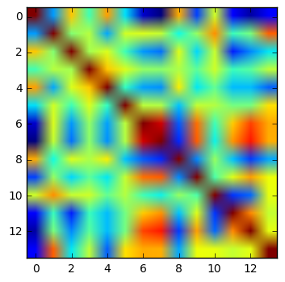

```python
from matplotlib import pyplot as plt
plt.imshow(Cov)
plt.show()
```

The following computes F-scores for individual ANOVAs for each variable by class. If you get finished early try to figure out what's going on.

```python
X = datmat.copy() #copy of orginal data matrix, not normalized one
N = np.array([(X[:,0] == i+1).sum() for i in range(3)])
'''
print sum(N) will give 178, the total number of observations
N holds the # of obs. for each class of wine.
'''
V = np.array([X[X[:,0] == i+1,1:].var(axis=0) for i in range(3)])
'''
V holds col. variance for each variable in 3x13 matrix
3 classes and 13 variables since it's by wine class.
'''
M = np.array([X[X[:,0] == i+1,1:].mean(axis=0) for i in range(3)])
#means for the 13 variables, same structure as V
Bvar = (((M - X[:,1:].mean(axis=0))**2.).T * N).sum(axis=1) / 2
#Variance between class
Wvar = (V.T * (N-1)).sum(axis=1) / (n - 3)
#Variance within class
F = Bvar / Wvar
#Bvar + Wvar = Total variance
```

```python
print F
```

```
[ 137.3861116    37.58265615   13.5260966    36.35357397   12.62981408
   95.24380219  237.53617769   28.0471868    30.76266898  122.99581166
  102.9202907   192.99700461  211.40023981]
```